# Multilevel Logistic Regression

## Load Packages and Import Data

```r
# To install a package, run the following ONCE (and only once on your computer)
# install.packages("psych")
library(here)  # makes reading data more consistent
library(tidyverse)  # for data manipulation and plotting
library(haven)  # for importing SPSS/SAS/Stata data
library(brms)  # for Bayesian multilevel analysis
# (Optional) Set multiple cores in global option
options(mc.cores = min(parallel::detectCores() - 1, 2L))
library(broom.mixed)  # for summarizing results
library(emmeans)  # for approximating population-average effect
library(modelsummary)  # for making tables
theme_set(theme_bw())  # Theme; just my personal preference
```

Here we consider those who score 20 or above for a “commended” status.

```r
# Read in the data (pay attention to the directory)
hsball <- read_sav(here("data_files", "hsball.sav"))
# Dichotomize mathach
hsball <- hsball %>%
  mutate(mathcom = as.integer(mathach >= 20))
```

Let’s plot the commended distribution for a few schools

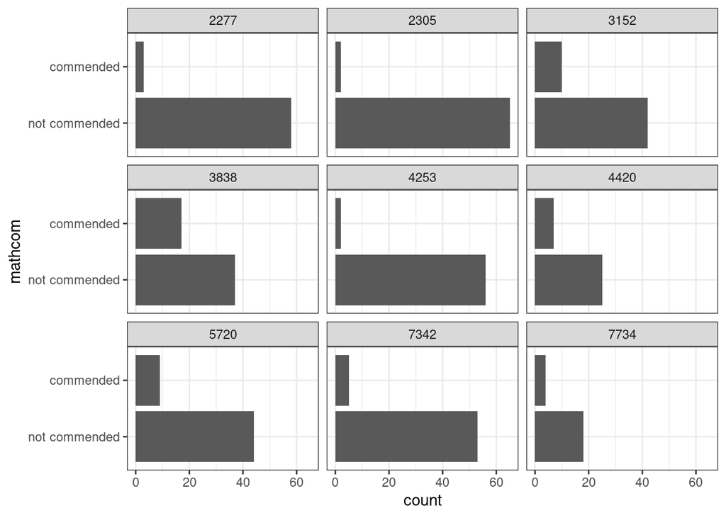

```r
set.seed(7351)
# Randomly select some schools
random_schools <- sample(hsball$id, size = 9)
hsball %>%
  filter(id %in% random_schools) %>%
  mutate(mathcom = factor(mathcom,
                          labels = c("not commended", "commended"))) %>%
  ggplot(aes(x = mathcom)) +
  geom_bar() +
  facet_wrap( ~ id, ncol = 3) +
  coord_flip()
```

### Problem of a Linear Model

Let’s use our linear model, and then talk about the problems. Let’s use `meanses` as predictor.

```r
m_lme <- brm(mathcom ~ meanses + (1 | id), data = hsball,
             seed = 1541)
```

```
># Compiling Stan program...
```

```
># Start sampling
```

So it runs, and it indicates a positive association between `meanses` and `mathcom`. Let’s plot the effect:

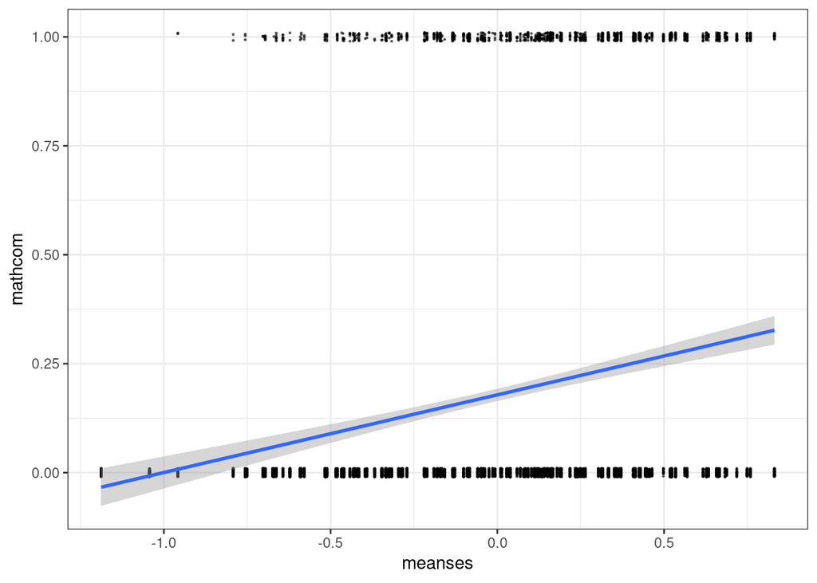

```r
plot(
  conditional_effects(m_lme, effects = "meanses"),
  points = TRUE,
  point_args = c(height = 0.01, size = 0.2, alpha = 0.5)
)
```

Well, this looks a bit strange. The outcome can only take two values, but the predictions are in decimals. We can assume may be we are predicting the probability of being commended for each student, but still there are some negative predictions that are not possible. For example, if we consider a school with `meanses` = -2, our prediction would be

```r
predict(m_lme, newdata = tibble(meanses = -2), re_formula = NA)
```

```
>#        Estimate Est.Error       Q2.5     Q97.5
># [1,] -0.1782145 0.3748479 -0.8905152 0.5613888
```

Another problem is that the data is not normally distributed. We can look at the distribution of the data (in darker line) and of simulated data based on the model (in lighter lines) below:

```r
pp_check(m_lme)
```

```
># Using 10 posterior samples for ppc type 'dens_overlay' by default.
```

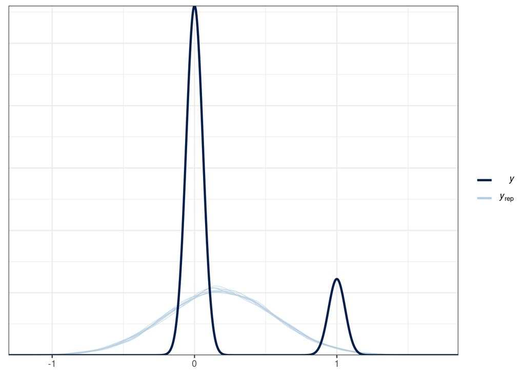

Another related and subtle problem is that the residual variance is not constant across levels of the predictor. For example, the residual variance for `meanses` $\leq$ -0.5 is

```r
augmented_data <-
  augment(m_lme)
augmented_data %>%
  filter(meanses <= -.5) %>%
  # extract the .resid column
  pull(.resid) %>%
  # residual variance
  var()
```

```
># [1] 0.05823324
```

But when `meanses > 0.5 it was

```r
augmented_data %>%
  filter(meanses > .5) %>%
  # extract the .resid column
  pull(.resid) %>%
  # residual variance
  var()
```

```
># [1] 0.193315
```

These are pretty large differences, and it happens every time one uses a normal linear model for a binary outcome. The textbook has more discussion on this.

So because of these limitations, we generally prefer models designed for binary outcomes, the most popular one is commonly referred to as a logistic model.

# Multilevel Logistic Regression

The logistic model modifies the linear multilevel model in two ways.

## Bernoulli Distribution

First, it replaces the assumption that the conditional distribution of the outcome is normal with one that says the outcome follows a *Bernoulli* distribution, which is a distribution for binary variables (e.g., outcome of a coin flip). Below is a comparison of a Bernoulli distribution (left) with mean = 0.8 (i.e., 80% success and 20% failure), which by definition has a standard deviation of 0.4, and a normal distribution (right) with a mean = 0.8 and a standard deviation of 0.4:

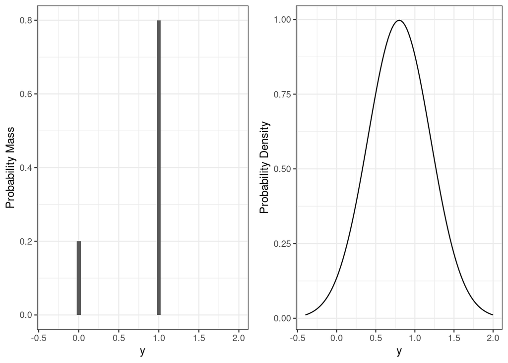

```r
p1 <- ggplot(tibble(y = c(0, 1), p = c(0.2, 0.8)), aes(x = y, y = p)) +
  geom_col(width = 0.05) +
  xlim(-0.4, 2) +
  labs(y = "Probability Mass")
p2 <- ggplot(tibble(y = c(0, 1)), aes(x = y)) +
  stat_function(fun = dnorm, args = list(mean = 0.8, sd = 0.4)) +
  xlim(-0.4, 2) +
  labs(y = "Probability Density")
gridExtra::grid.arrange(p1, p2, ncol = 2)
```

With the Bernoulli distribution, the possible values are only 0 and 1, so it matches the outcome.

## Transformation

Second, instead of directly modeling the mean of a binary outcome (i.e., probability), which is bounded between 0 and 1, a logistic model transforms the mean of the outcome into something that is unbounded (i.e., with range between $-\infty$ and $\infty$). We can this $\eta$. One common transformation that would do this is the logit transformation, which converts a probability into odds, and then to log odds:
$$\text{Log Odds} = \log \left(\frac{\text{Probability}}{1 - \text{Probability}}\right)$$

As shown below,

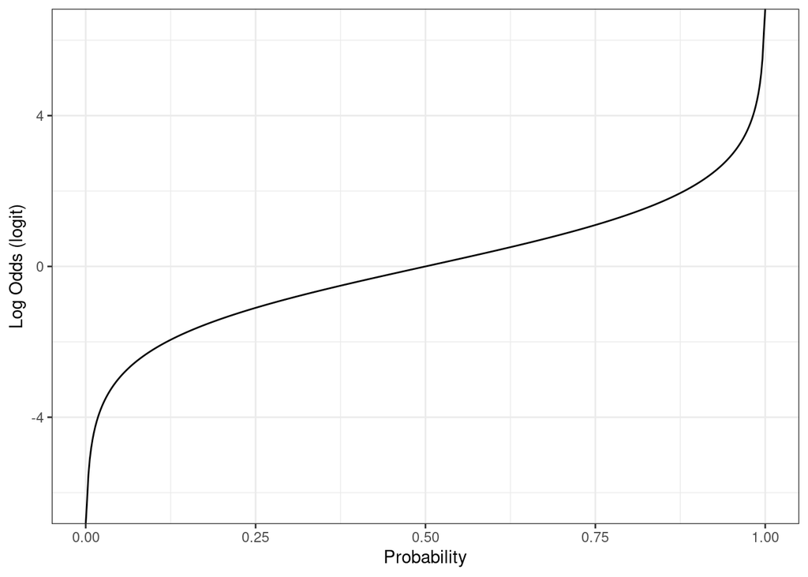

```r
ggplot(tibble(mu = c(0, 1)), aes(x = mu)) +
  stat_function(fun = qlogis, n = 501) +
  labs(x = "Probability", y = "Log Odds (logit)")
```

## Model Equation

To understand the equation for a logistic model, it helps to write the normal linear model in its full form by specifying the distributions. Let’s look at the simplest unconditional model without predictors. First, we can write
$$\text{mathcom}_{ij} = \mu_{ij} + e_{ij}, \quad e_{ij} \sim N(0, \sigma),$$
where $\mu_{ij}$ is the predicted value of `mathcom` for the $i$th individual in the $j$th school. This is equivalent to saying
$$\text{mathcom}_{ij} \sim N(\mu_{ij}, \sigma),$$
because if a variable is normal with a mean 0, adding a value to it changes its mean, but it will still be normal. This says `mathcom` is normally distributed around the predicted value with an error variance of $\sigma$. The predicted value is separated into level 1
$$\begin{aligned}
\text{mathcom}_{ij} & \sim N(\mu_{ij}, \sigma) \\
\mu_{ij} & = \beta_{0j}
\end{aligned}$$
and level 2
$$\beta_{0j} = \gamma_{00} + u_{0j}$$
You can convince yourself that this is the same model you’ve seen in Week 3.

Now, we’ll change the distribution of `mathcom`, and transform $\mu_{ij}$ from probability to log odds:

Level 1
$$\begin{aligned}
\text{mathcom}_{ij} & \sim \text{Bernoulli}(\mu_{ij}) \\
\eta_{ij} & = \text{logit}(\mu_{ij}) \\
\eta_{ij} & = \beta_{0j}
\end{aligned}$$
Level 2
$$\beta_{0j} = \gamma_{00} + u_{0j}$$
The level-2 equation has not changed, but the meaning of $\beta_{0j}$ is different now: it is the cluster mean of cluster $j$ in the log odds unit.

## Using `brms`

With logistic regression, frequentist methods rely on approximations that are sometimes problematic and give biased results. I recommend instead using Bayesian estimation, such as with `brms`. The only thing you need to change is to specify `family = Bernoulli("logit")`

### Unconditional Model

```r
# Recode into factor
hsball$mathcom <- factor(hsball$mathcom, levels = c(0, 1),
                         labels = c("not commended", "commended"))
```

```r
m0_logit <- brm(mathcom ~ (1 | id),
               data = hsball,
               family = bernoulli("logit"),
               seed = 1541)
```

```
># Compiling Stan program...
```

```
># Start sampling
```

By definition, $\sigma$ is fixed to be $\pi^2 / 3$ in the log-odds unit in a logistic model. Therefore, the ICC is

```r
post_tau <- posterior_samples(m0_logit, pars = c("sd"))
# Posterior of ICC: tau_0^2 / (tau_0^2 + sigma^2)
icc_samples <- post_tau$sd_id__Intercept^2 /
  (post_tau$sd_id__Intercept^2 + pi^2 / 3)
# Posterior summary of ICC
posterior_summary(icc_samples)
```

```
>#       Estimate  Est.Error      Q2.5     Q97.5
># [1,] 0.1498612 0.02141061 0.1108284 0.1955525
```

### With Lv-2 and Lv-1 Predictors

```r
hsball <- hsball %>%
  group_by(id) %>%   # operate within schools
  mutate(ses_cm = mean(ses),   # create cluster means (the same as `meanses`)
         ses_cmc = ses - ses_cm) %>%   # cluster-mean centered
  ungroup()  # exit the "editing within groups" mode
```

```r
m1_logit <- brm(mathcom ~ meanses + ses_cmc + (ses_cmc | id),
                data = hsball,
                family = bernoulli("logit"),
                seed = 1541)
```

```
># Compiling Stan program...
```

```
># Start sampling
```

```r
summary(m1_logit)
```

```
>#  Family: bernoulli
>#   Links: mu = logit
># Formula: mathcom ~ meanses + ses_cmc + (ses_cmc | id)
>#    Data: hsball (Number of observations: 7185)
># Samples: 4 chains, each with iter = 2000; warmup = 1000; thin = 1;
>#          total post-warmup samples = 4000
>#
># Group-Level Effects:
># ~id (Number of levels: 160)
>#                        Estimate Est.Error l-95% CI u-95% CI Rhat Bulk_ESS Tail_ESS
># sd(Intercept)              0.52      0.05     0.42     0.64 1.00     1220     2226
># sd(ses_cmc)                0.11      0.07     0.01     0.26 1.01     1164     1319
># cor(Intercept,ses_cmc)    -0.48      0.44    -0.98     0.72 1.00     2234     2064
>#
># Population-Level Effects:
>#           Estimate Est.Error l-95% CI u-95% CI Rhat Bulk_ESS Tail_ESS
># Intercept    -1.76      0.06    -1.87    -1.65 1.00     1840     2199
># meanses       1.45      0.14     1.19     1.73 1.00     1801     2381
># ses_cmc       0.59      0.06     0.48     0.71 1.00     3791     2775
>#
># Samples were drawn using sampling(NUTS). For each parameter, Bulk_ESS
># and Tail_ESS are effective sample size measures, and Rhat is the potential
># scale reduction factor on split chains (at convergence, Rhat = 1).
```

### Interpretations

#### Intercept

For schools with `meanses` = 0, the average log odds of being commended was -1.7571998, 95% CI [-1.8715416, -1.6489205].

#### Slope

A unit increase in `meanses` is associated with an increase in log odds of 1.4546341 of being commended, 95% CI [1.1888783, 1.7303116].

#### Odds ratio

A unit increase in `meanses` is associated with the odds of being commended multiplied by 4.282916, 95% CI [3.2833963, 5.6424117].

### Plotting

Plotting is especially important with transformation, as it shows the association in probability unit

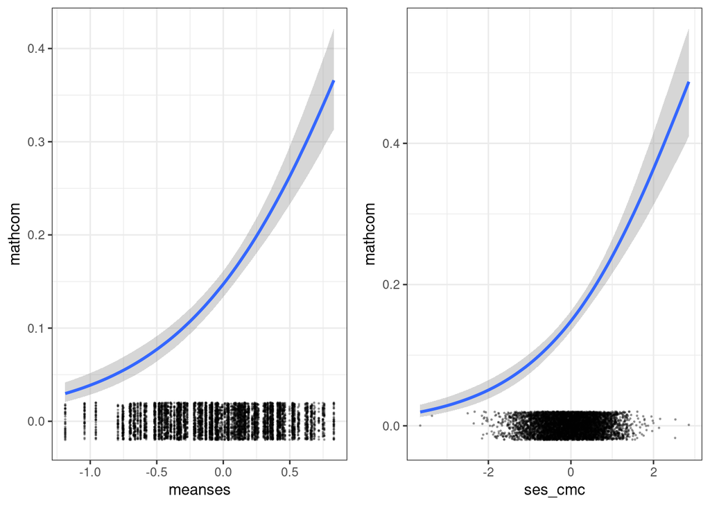

```r
m1_plots <- plot(
  conditional_effects(
    m1_logit
  ),
  points = TRUE,
  point_args = c(height = 0.02, alpha = 0.3, size = 0.2),
  plot = FALSE
)
gridExtra::grid.arrange(grobs = m1_plots, ncol = 2)
```

### Predicted probabilities with representative values

```r
# meanses = 0; ses_cmc = -0.5 vs 0.5
pred_df1 <- expand_grid(meanses = 0,
                        ses_cmc = c(-0.5, 0.5))
cbind(pred_df1,
      predict(m1_logit, newdata = pred_df1, re_formula = NA))
```

| meanses | ses_cmc | Estimate | Est.Error | Q2.5 | Q97.5 |
| --- | --- | --- | --- | --- | --- |
| 0 | -0.5 | 0.11625 | 0.3205645 | 0 | 1 |
| 0 | 0.5 | 0.17750 | 0.3821391 | 0 | 1 |

```r
# meanses = -0.5 vs 0.5; ses_cmc = 0
pred_df2 <- expand_grid(meanses = c(-0.5, 0.5),
                        ses_cmc = 0)
cbind(pred_df2,
      predict(m1_logit, newdata = pred_df2, re_formula = NA))
```

| meanses | ses_cmc | Estimate | Est.Error | Q2.5 | Q97.5 |
| --- | --- | --- | --- | --- | --- |
| -0.5 | 0 | 0.07000 | 0.2551789 | 0 | 1 |
| 0.5 | 0 | 0.25925 | 0.4382778 | 0 | 1 |